# Analysis of domain data for suspected sources of disinformation

Trevor J. McGlynn

2020-10-29

# Introduction

The following EDA explores the data collected and lays the ground work for the modeling to following. This is part exploratory, part auditing of the data to ensure its accuracy. We’ll try to see what initial signals may be worth looking more deeply at and provide a starting point for how the eventual learned function may operate.

# Analysis

## Univariate analysis

The following plots consider single-variable investigations into the data collected. Most of the data points investigated deal exclusively with domains that have an initial `trust score` of “fake” as the classification of these types of domains are exactly what the learned function will need to categorize. DNSSec was also analyzed, mostly for identification of false positives, and while a write up is not included, the plot can still be seen. ### Trust

| Trust rating | Count | Proportion |
| --- | --- | --- |
| initial trust | 24870 | 0.91229229 |
| fake | 2391 | 0.08770771 |

Out of the sample of domains that were collected, 24870 were classified “initial trust”, while 2391 were classified as “fake” (or 8.77% of the sample). Limitations on collection have more to do with internet connectivity in northeastern Vermont than limitations set by the project. Ideally, more data will be added as the project continues

### Countries

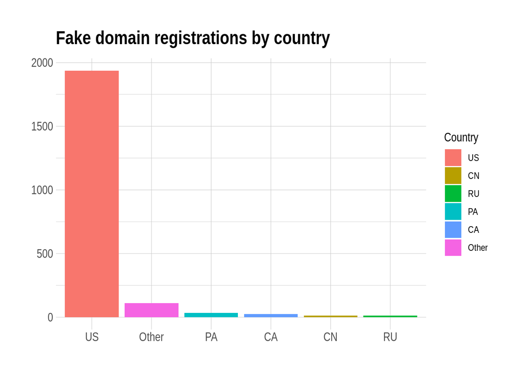

Overwhelmingly, registration records point to the United States for being the country with the most registrations of disinformation. There are a few factors to consider with this in mind: * A large portion of the fake domains are shell local news websites which focus on US metropolitan markets. The organization responsible for these shell publications–Metric Media–is based in the United States. * It is very plausible (and easy) for those registering the sites to say that they are a US-based operation, and it does not seem like the United States (or its registrars) really seem to care, or do anything about influence operations. * The United States is a frequent target for influence operations, partly because country leadership does not care or does not recognize the issue, and partly because influencing Americans is both very beneficial to stakeholder nations and very easy for them to do. * Some countries, such as Russia, prefer targeting social media, especially influential users, to drive their narratives.

### TLDs

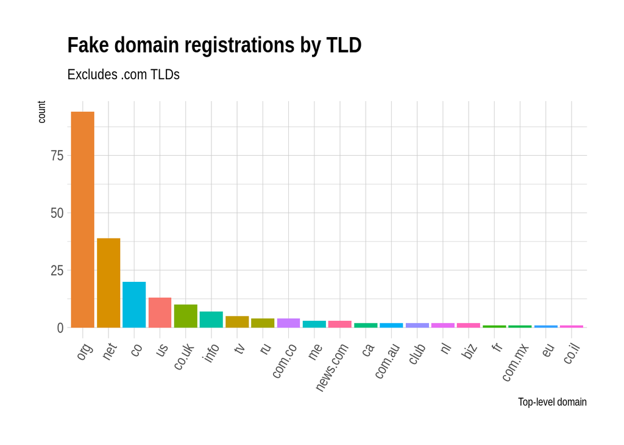

### Registrars

| Registrar | Count | Proportion |
| --- | --- | --- |
| godaddycom llc | 1739 | 0.727310749 |
| namecheap inc | 79 | 0.033040569 |
| enom inc | 38 | 0.015892932 |
| network solutions llc | 35 | 0.014638227 |
| tucows domains inc | 31 | 0.012965286 |
| dynadot llc | 20 | 0.008364701 |
| fastdomain inc | 17 | 0.007109996 |
| wild west domains llc | 17 | 0.007109996 |
| 11 ionos se | 16 | 0.006691761 |
| pdr ltd dba publicdomainregistrycom | 16 | 0.006691761 |

[output cut: 10 more lines]

Most legitimate domains seems to use a widespread of registrars for their needs. Domains pushing influence operations, however, overwhelmingly use GoDaddy.com. The difference is pretty telling: for domains labeled “initial trust”, 17.31% were registered with GoDaddy; for domains labeled “fake”, 72.73% were registered with GoDaddy. There may be a correlation with the popularity of a domain provider and its trustworthiness.

### Google Analytics

| Organization | Domain cluster | Count |
| --- | --- | --- |
| 146478383 | antelopevalleytoday.com, centraloctimes.com, coachellatoday.com, eastsandiegonews.com, eastsbvtimes.com, eastsfvtoday.com, eastsierranews.com, eastventuranews.com, fresnoleader.com, imperialcanews.com… | 50 |
| 146493041 | interioralaskanews.com, lastfrontiernews.com, matsutimes.com, northalaskanews.com, scalaskanews.com, sealaskanews.com, swalaskanews.com, centralalamedanews.com, chicotimes.com, eastalamedanews.com, ea… | 50 |
| 147358532 | austintxnews.com, collintimes.com, conchovalleynews.com, corpuschristisun.com, dallascitywire.com, ectexasnews.com, eastdfwnews.com, easthoustonnews.com, eastrgvnews.com, elpasostandard.com, farwesttx… | 50 |
| 147966219 | amestoday.com, cedarrapidstoday.com, centraliowatimes.com, desmoinessun.com, dubuquetimes.com, eciowanews.com, hawkeyereporter.com, iowacitytoday.com, neiowanews.com, northdsmnews.com, northiowareport… | 50 |
| 151930833 | akronreporter.com, butlercountytoday.com, cantonreporter.com, centralohiotoday.com, cincyreporter.com, clermonttimes.com, clevelandreporter.com, daytonreporter.com, delcoreview.com, eastclevelandnews.… | 50 |
| 151937292 | andersonreporter.com, bloomingtonleader.com, columbusstandard.com, eastindynews.com, ecindiananews.com, elkharttimes.com, ftwaynetimes.com, hoosierstatetoday.com, indystandard.com, kentuckianatimes.co… | 49 |
| 151957030 | brevardsun.com, centralbrowardnews.com, claycotimes.com, duvaltimes.com, easthillsboroughnews.com, eastpanhandlenews.com, eastvolusianews.com, emeraldcoasttimes.com, hernandoreporter.com, keywestrepor… | 49 |
| 151974759 | altoonatimes.com, beaverconews.com, berksconews.com, butlerconews.com, cambriatimes.com, centralbuckstoday.com, centralchestertoday.com, centralpanews.com, coalregionnews.com, crawfordtimes.com, cumbe… | 49 |
| 151979212 | bridgeporttimes.com, constitutionstatenews.com, hartfordreporter.com, housatonicvalleynews.com, litchfieldhillstoday.com, naugatucktimes.com, neconnnews.com, nwconnnews.com, scconnnews.com, seconnnews… | 49 |
| 151985462 | atlanticcotimes.com, burlingtonreview.com, gardenstatetimes.com, gloucestertoday.com, hudsontoday.com, mercertimes.com, monmouthtimes.com, morrisleader.com, nebergennews.com, newarkreporter.com, north… | 49 |

[output cut: 29 more lines]

Using the data frame above, one can see the collections of sites grouped together by their organization’s GA identifier. A cursory glance of the domain clusters reveals groupings which more of less exist as topical containers for their targeted state of industry. Many of these, it appears, come from the data set of fake local news companies. Apparently when this was setup by metric media, it seems like they had a goal of up to 50 shell sites for each of the fifty states. All of these are tied to the same organization, with a unit ID for the locations or industries targeted in the operation. This analysis identified 39 clusters of influence operations accounting for 48.98% of all fake domains captured.

### Words used in domain name

[figure not shown]

## Bivariate analysis

### Density of domain registations over time

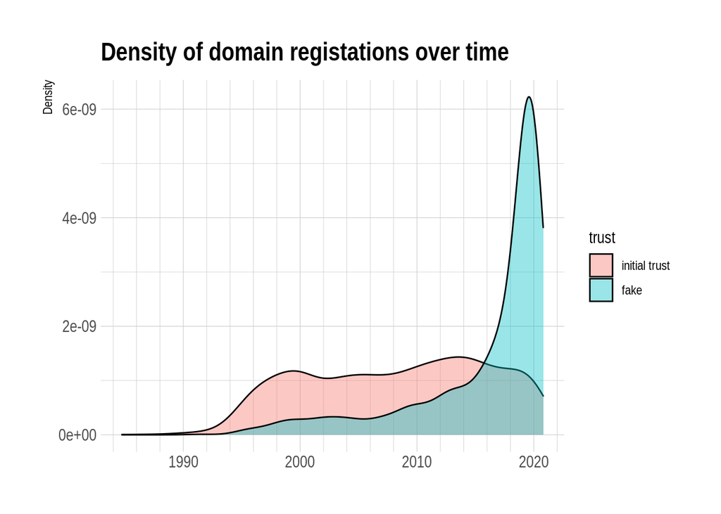

Where trustworthy domains registrations have remained more or less evenly distributed across time, registrations for domains labeled fake have very clearly spiked over the course of the past four years, with increasing acceleration staring after 2010 and trending sharply upward starting around 2014. This goes in line with much of the research conducted on the issue, so there’s even less potential to have concern about the data included within the sample. The downward trend stating around the turn of 2020 could be explained as 1.) Influence operations preparing for the 2020 elections, and/or 2.) lack of detection because as new domains are activated.

### Density of registation update to expirations

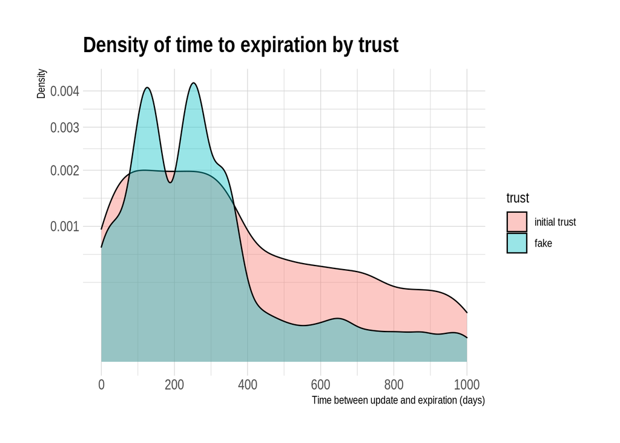

The second plot measures the density of times between an update to a site’s registration and its expiration. This time frame is influenced predominantly by the registrar; trustworthy sites will more likely have long-term management of this while fake sites registered with, say, GoDaddy.com, will typically be using a 1 year registration period. It that’s so, we could expect to align the peak of registrations with the density peaks in this plot. A cursory glance at this plot seems to confirm some of the timelines.

### Domain age by Alexa site ranking

[figure not shown]

This plot seems to have a fair amount of statistical noise and, purely from an auditing perspective, confirms information known already: many sites labeled “fake” do not have domain ranking through Alexa (unless, of course, they become enormously popular), and those that do seem to have some amount of staying power. The domains in this sample are mostly more than 5 years old, but it is also known that the bulk of the domains in the sample were registered within that time.

### Number of nameservers by domain trustworthiness’

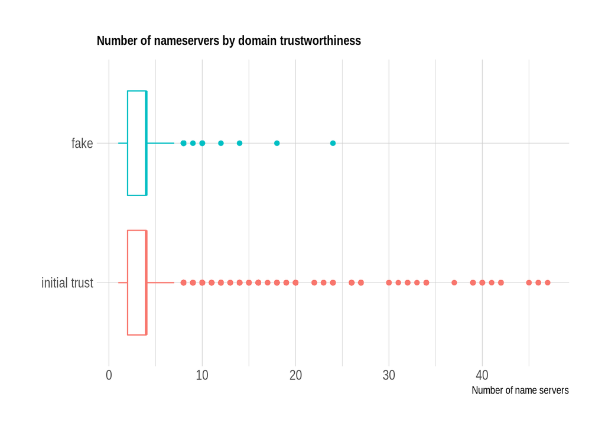

Number of name servers could have some indication on the reliability of a site. Again, a lot of this comes down to the registrar used by the domain, but it doesn’t seem unreasonable to associate sites with >= 5 nameservers to be functioning in a legitimate capacity.

## Multivariate analysis

### Domain keyword length by domain age

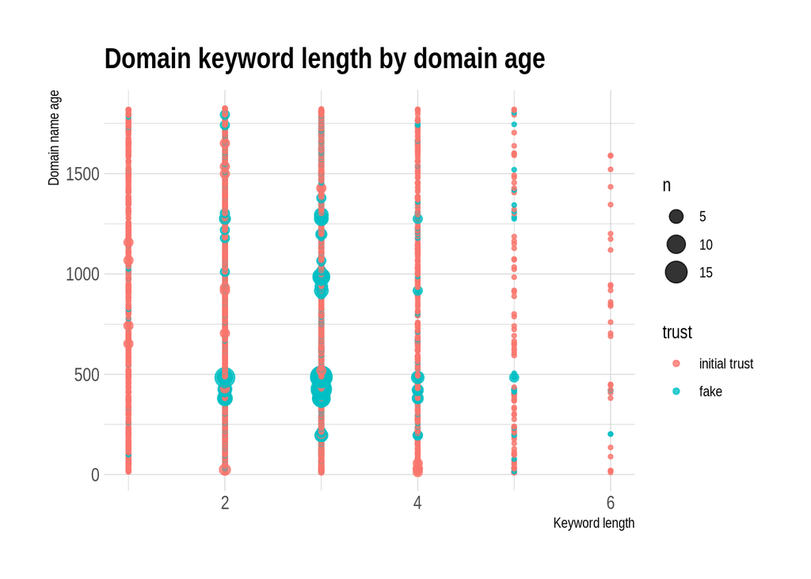

Of domains registered in the past 5 years, domain registration by veracity seems to cluster around certain periods, while keyword length seems to have some bearing on veracity. This seems obvious as a disinformation campaign domain name might attempt to validate itself by explaining more (in the domain name itself) what its intentions are. Also worth noting, as far as a correlation of date of registration, that a single influence operation (by Metric Media) accounts for a large portion of fake domains. These coordinated campaigns are signaled by the clustering of their registrations

### Domain length by domain keyword length, by trust

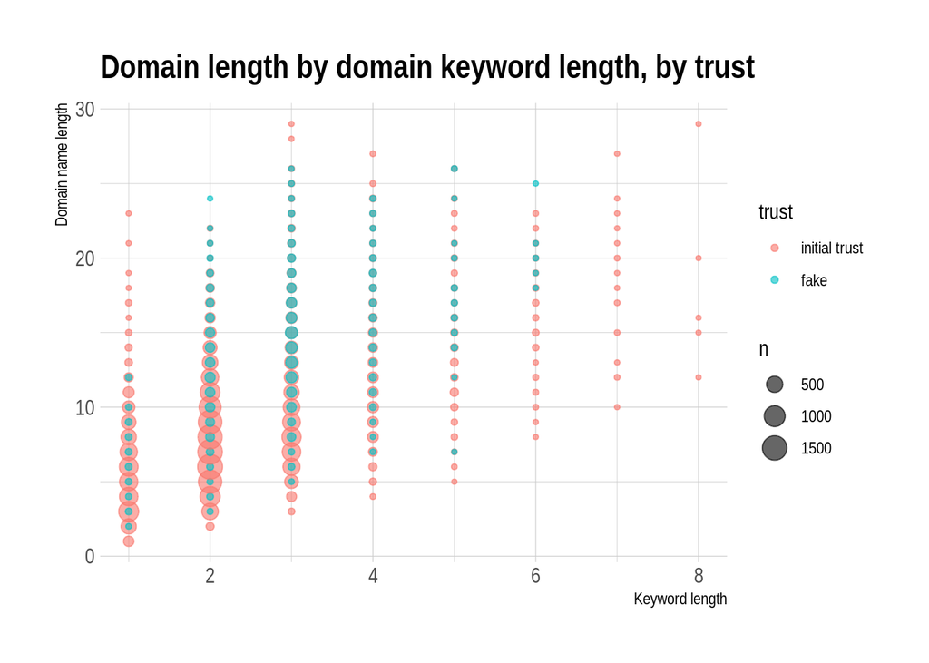

Looking at domain length by keyword length shows a more clear relationship between the length of a domain, its keywords, and its trustworthiness. This chart looks like a perfect opportunity for modeling!

### GoDaddy.com, fake registrations

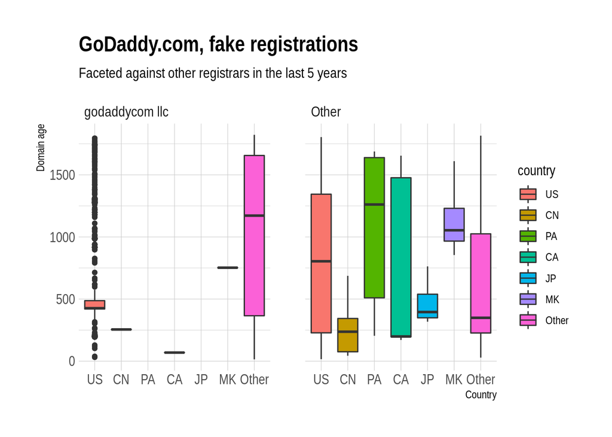

GoDaddy is emerging as a perfectly complacent registrar for domain fake domain registrations, disproportionate to its market share. Registrations in this chart cluster perfectly with the densities of fake registrations from above, and it might not be a reach to say that the successes in these campaigns may replicate in Canada after the US. Interestingly, when filtering for fake domains registered in the past five years, Russia fell off the map of countries represented. However, the author stresses that Russia’s strategies, and their historic successes, have been in targeted agent of influence operations, for which social media is much more effective and far more exploitable than domain names.

# Conclusion

There is more to be revealed as the data enter the modeling stages. However, there do seem to be a few initial signals in the data worth noting * Though GoDaddy is the most popular registrar on the Web, it is disproportionately exploited for the use of propagating misinformation, especially within the past 5 years * The length of a domain name and the number of keywords it uses seem to have a clear bearing on the trust score of a website * The United States seems to be the most responsible for domain-affiliated disinformation campaigns, especially those involving fake local news organizations. Russian APTs are not being used to drive this content, most of which seems decidedly American * Keyword analysis may be a driving factor in the categorization of disinformation websites * For records management, established sites do consistently better at updating and maintaining their registrations. Furthermore, and for untrustworthy domains, their is more of a tendency for expirations to cluster around a mean–this is due to coordination of registrations, such as registering a bunch of fake local news sites all around the same time frame * Legitimate sites use appopriate amounts of name servers for their needs. Non-legitimate sites use (more or less) the same number across the board (provided by the registrar)

This concludes the EDA for the curated data. Next comes modeling!